# Notebook

**Research Question:** "What does the r/covidlonghaulers community report about Mestinon (pyridostigmine) as a Long COVID treatment, and how does that signal compare to low-dose naltrexone (LDN) — the other arm of the NIH LIFT trial?"

## Abstract

Mestinon (**pyridostigmine**) — a cholinergic drug long used for myasthenia gravis and dysautonomia — is one of two interventions in the NIH-funded **LIFT** trial for Long COVID, paired with low-dose naltrexone (**LDN**). We mined first-person treatment reports from **r/covidlonghaulers** (Jul 2020–Dec 2022) with an LLM extraction-and-sentiment pipeline, then aggregated to **one outcome per user** for statistical independence.

At the report level Mestinon looks favorable (74% of 181 reports positive), but collapsed to **one vote per user (n = 49)** the positive rate falls to **55%** — a positive lean that does **not** reach significance against a coin-flip (binomial p = 0.57), because a handful of enthusiastic repeat-posters inflate the report count. LDN, by contrast, sits clearly above chance (**64.5%** of 321 users, p < 1e-6). The two cannot be statistically distinguished (Fisher p = 0.21), but that reflects Mestinon's wide confidence interval, not proven equivalence.

Mestinon's responses are **polarized** — most users land in "clearly helped" or "clearly didn't," with few in between — and patients overwhelmingly frame it as a **POTS / dysautonomia** tool. **Verdict:** a promising but underpowered, not-yet-significant community signal — reasonable to watch (and precisely what LIFT is built to test), not a proven win.

## 1 · Why Mestinon, and why now

Long COVID has no approved treatment, and the trials that might find one are expensive and slow. One way to spend that money better is to ask what patients already report from off-label drugs they try on their own. **Mestinon (pyridostigmine)** is a natural test case: it boosts acetylcholine signalling, is cheap and generic, and is widely used for **POTS** (postural orthostatic tachycardia syndrome) and other dysautonomia — symptoms that overlap heavily with Long COVID. The NIH's **LIFT** trial is now testing it head-to-head with low-dose naltrexone.

This notebook asks a narrow question: in the largest Long COVID community on Reddit, what do people say happened when they took it — and does that signal hold up to the same scrutiny we apply to LDN?

**Community:** r/covidlonghaulers | **Data covers:** 2020-07-24 to 2022-12-31 (~29 months)

**First-person treatment reports — the two LIFT-trial drugs**

| Drug | Reports | Users |
| --- | --- | --- |
| naltrexone | 1316 | 321 |
| pyridostigmine | 181 | 49 |

## 2 · Baseline: what 49 users actually reported

Before comparing anything, here is the raw shape of the Mestinon signal. We collapse every user's reports into a single outcome — their average sentiment, classified as **clearly positive**, **mixed / neutral**, or **clearly negative** — so a heavily-posting user counts once, not ten times.

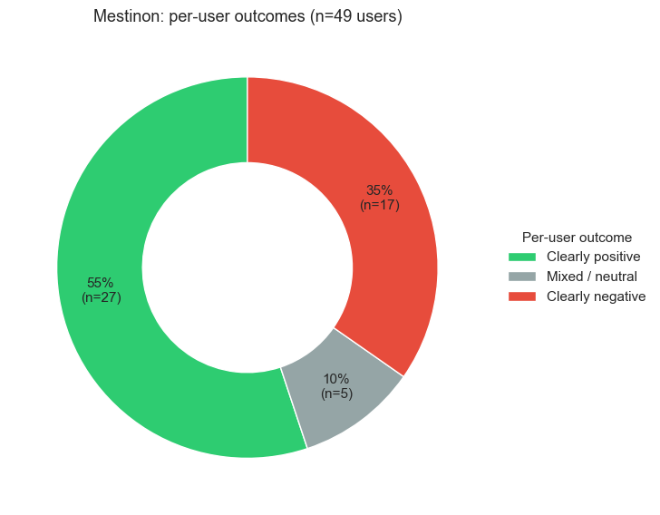

**What this shows:** Of 49 users, 27 (55%) landed clearly positive and 17 (35%) clearly negative — only 5 sat in the middle. Responses are **polarized**: people tend to either clearly benefit or clearly not.

## 3 · Does the signal beat chance — and how does it compare to LDN?

A positive lean only matters if it is bigger than a coin-flip and survives comparison to a drug we already trust. We test Mestinon's per-user positive rate against a 50% null (binomial test, Wilson 95% CI), then compare it directly to LDN (Fisher's exact) — the two arms of LIFT.

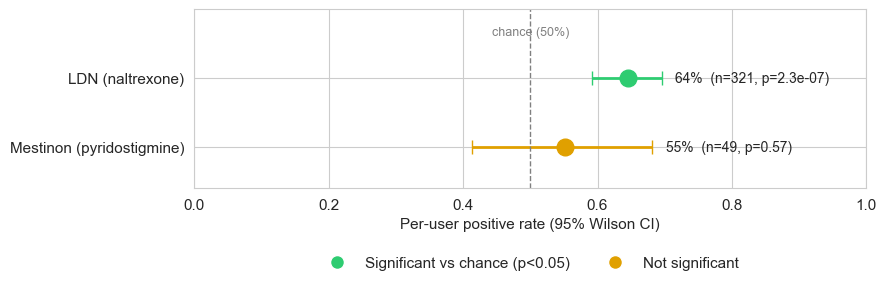

**Verdict:** Mestinon's per-user positive rate is **55%** (95% CI 41%–68%). That interval **straddles 50%**, so we cannot say it beats chance (binomial p = 0.57). LDN's rate is 64% (CI 59%–70%) and clears chance decisively (p < 1e-6).

Head-to-head, the two are **not statistically distinguishable** (Fisher's exact p = 0.21, odds ratio 0.68, Cohen's h = -0.19 — a small effect) — but that is because Mestinon's sample is small and its CI wide, **not** proof they are equal. In practical terms, at 55% versus a coin-flip you would need to treat about **20** people for one extra person to report benefit beyond chance, and even that gap is not statistically reliable here.

**Sensitivity:** restricting to strong-signal reports only (n=29 users) gives a 62% positive rate — in the same range as the main estimate, so the lean is not an artifact of weak or ambiguous mentions.

## 4 · Counterintuitive findings worth investigating

**The headline number shrinks under scrutiny.** At the report level Mestinon is 74% positive (134 of 181 reports); at the user level it is 55%. The gap is not a glitch — it is a few users posting several enthusiastic reports each. Whenever a community signal looks strong, this is the first thing to check, and here it changes the conclusion (significant → not).

**Mestinon behaves like a subtype drug, not a Long COVID drug.** The per-user outcomes are bimodal — clear winners and clear losers, few in between — and nearly every positive report ties the benefit to **POTS / dysautonomia** specifically (orthostatic intolerance, fight-or-flight, exercise tolerance), not Long COVID broadly. We cannot prove mechanism from text, but this is the pattern you would expect if the drug helps a specific subgroup rather than everyone — which is the explicit bet of the LIFT trial. (The timing below is a caveat, not a finding: most reports cluster in late 2022.)

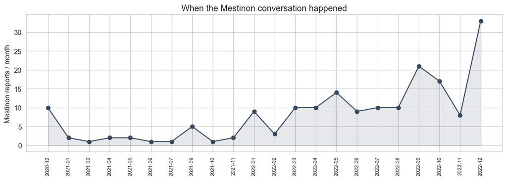

**What this shows:** 79 of 181 Mestinon reports (44%) fall in the last four months of the data (Sep–Dec 2022), and the series is still climbing at the cutoff. The signal is real but **recent and growing** — a snapshot, not a settled verdict.

## 5 · Which symptoms predict a response? A first subtype cut

Section 4 argued that Mestinon behaves like a subtype drug. Here we test that directly. Each Mestinon user is tagged by scanning all of their r/covidlonghaulers posts for symptom clusters drawn from pyridostigmine's pharmacology — it raises acetylcholine at autonomic ganglia, the neuromuscular junction, and peripheral muscarinic sites. We group the autonomic features (orthostatic / POTS *and* blood pooling / vascular tone are one mechanism), drop GI (which does not track benefit and separately predicts side effects), and ask whether each cluster reports benefit more often than **the rest of the Mestinon users** — baseline = the overall 55% positive rate:

- **Autonomic / dysautonomia** — orthostatic intolerance, POTS, syncope, palpitations, blood pooling, mottling, cold / purple extremities, Raynaud's
- **Exertional dyspnea / exercise intolerance** — air hunger, shortness of breath, post-exertional crashes
- **Neuromuscular (myasthenia-like)** — muscle weakness, droopy neck, ptosis, double vision, swallowing trouble

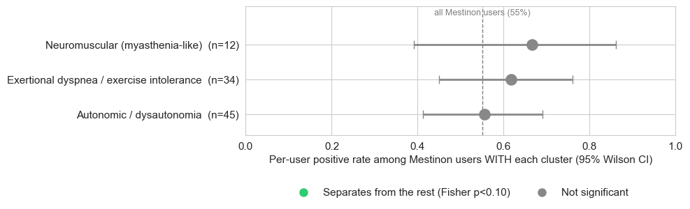

**Per-user positive rate by symptom cluster vs the rest of the Mestinon users (baseline 55%)**

| Symptom cluster | Positive rate (has cluster) | Rest of Mestinon users | Fisher p |
| --- | --- | --- | --- |
| Autonomic / dysautonomia | 25/45 = 56% | 50% (n=4) | 1 |
| Exertional dyspnea / exercise intolerance | 21/34 = 62% | 40% (n=15) | 0.22 |
| Neuromuscular (myasthenia-like) | 8/12 = 67% | 51% (n=37) | 0.51 |

**Verdict:** 45 of 49 Mestinon users (92%) describe autonomic / dysautonomia symptoms — the drug's audience essentially *is* the dysautonomia population, so that group's 56% positive rate just mirrors the 55% baseline (only 4 users lack autonomic features, too few to compare). By who takes it, Mestinon is already a dysautonomia drug.

What might *further* separate responders is the rest of the cholinergic picture. Among Mestinon users, those who also report **exertional intolerance** (62%) or **neuromuscular / myasthenia-like features** (67%) sit above the 55% baseline — the mechanism-linked direction — but neither separates from the rest at p<0.05 at this sample size. Treat it as a hypothesis for a larger cohort, not a result. (Caveats: the clusters overlap, and a symptom can be named *because* the drug helped it, inflating that cluster's rate.)

## What patients are saying

Representative first-person reports from the corpus (verbatim, dated). At least one complicates the positive story.

POSITIVE · POTS · 2020-12-13

“I am almost at 10 months now. Two months ago a doctor diagnosed me with POTS. I now take mestinon 3x a day and it has helped a lot!”

POSITIVE · POTS / autonomic · 2022-01-11

“i have had success with mestinon. it is a vagal nerve stimulator and has helped my fight or flight response as well as my POTS”

POSITIVE · breathing · 2022-03-12

“I had awful shortness of breath that only got better with pyridostigmine and physical therapy. I can do two flights of stairs with minimal SOB now.”

COMPLICATING · benefit + side effect · 2022-12-25

“worked incredibly well for POTS and exercise tolerance but gave me blurry vision. So unfortunate for me because otherwise it was a miracle drug.”

NEGATIVE · lost gains, POTS worse · 2022-09-18

“It erased most of the improvements in my fatigue, and temporarily made my POTS worse.”

## 6 · Conclusion

What keeps Mestinon interesting is not the headline rate but the **shape** of the response: it is polarising, and the wins cluster around POTS and orthostatic symptoms. That is consistent with a drug that helps a specific Long COVID subtype rather than the whole population — which is exactly why the NIH LIFT trial is testing it. Our data cannot confirm that; it can only say the community signal points that way.

Tiered recommendation

| Drug | Users | Positive rate | 95% CI | vs chance (p) | Tier | Plain-language verdict |
| --- | --- | --- | --- | --- | --- | --- |
| LDN (naltrexone) | 321 | 64% | 59%–70% | 2e-07 | STRONG | Clearly above chance; the more established option of the pair. |
| Mestinon (pyridostigmine) | 49 | 55% | 41%–68% | 0.57 | PRELIMINARY | Positive lean, not significant; promising for POTS/dysautonomia, unproven. |

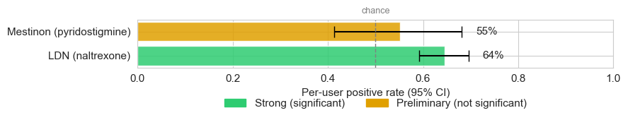

## Research limitations

This reflects what people choose to write online, not a controlled study:

- **Selection bias** — r/covidlonghaulers users are not a random sample; they skew severe, persistent, and internet-active.
- **Reporting bias** — dramatic outcomes (big help, bad reaction) get posted more than non-events; the middle is under-reported.
- **Survivorship bias** — people who recovered or gave up may stop posting, over-representing the still-struggling.
- **Recall bias** — reports are retrospective and unverified; doses, timing, and outcomes are as-remembered.
- **Confounding** — almost everyone takes several things at once (Mestinon with LDN, beta-blockers, midodrine…); we cannot isolate Mestinon's effect.
- **No control group** — there is no placebo arm; a 55% positive rate has nothing to be 55% *better than*.
- **Sentiment ≠ efficacy** — we measure how people *describe* an outcome, not a clinical endpoint.
- **Temporal snapshot** — data ends Dec 2022, most reports from its final months; a moving conversation caught mid-stride.

On top of these the **sample is small (49 users)** and the headline depends on the unit of analysis (report vs user) — reasons to treat every number here as directional.

These findings reflect reporting patterns in online communities, not population-level treatment effects. This is not medical advice.